# {ggplot2}

# Basic {ggplot2] concepts

`{ggplot2}` builds complex plots using layers. For building a ggplot we only need two functions, but first a dataset!

```r
library(tidyverse)

df<- data.table::fread("data/gdp2v.csv") %>%
  filter(unit=="PPS_HAB_EU27_2020") %>%
  mutate(country=str_sub(geo,1,2),
         NUTS=str_length(geo)-2) %>%
  filter(NUTS=="2" & country =="ES") %>%
  select(-obs_decimals,-obs_status, -unit,-NUTS) %>%
  filter(time == 2000 | time == 2019) %>%
  select(geo,time,obs_value) %>%
  pivot_wider(names_from=time,
              values_from=obs_value,
              names_prefix = "y")
```

## ggplot

- The ggplot function specifies the dataset we want to use (`data`).
- The mapping of the variables to the aesthetic (`aes`)

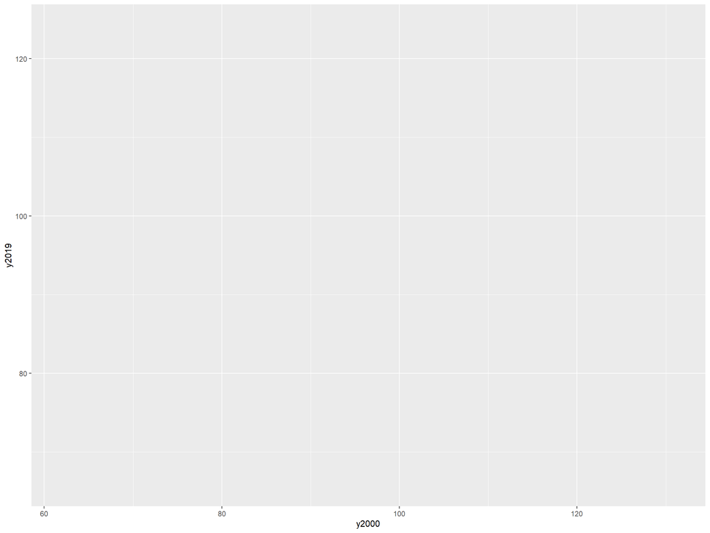

Map variables

```r
ggplot(data = df,
       mapping = aes(x= y2000, y= y2019))
```

We have an empty chart with the information we have provided and what is in the x and y axis.

## geom_

Now we have to tell `ggplot` which `geom` to use for showing the observations (lines, dots, areas). The `geom` we choose will depend partially on the kind of data we have and what we want to display. They are added using functions that start with `geom_` and functions are chained with a `+`. In this case, we add a point with `geom_point`.

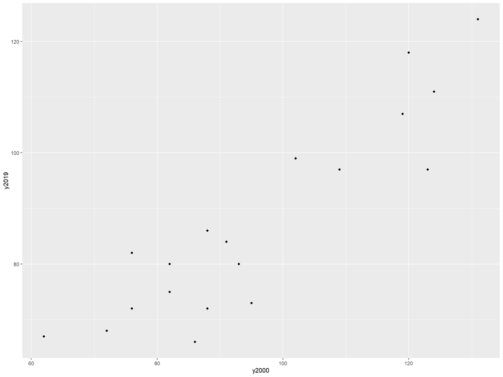

Add geom point

```r
ggplot(data = df,
       mapping = aes(x= y2000, y= y2019))+
  geom_point()
```

We can easily change these parameters to obtain other kind of charts. Sometimea it will involve changing the dataset we pass to ggplot (long or wide format)

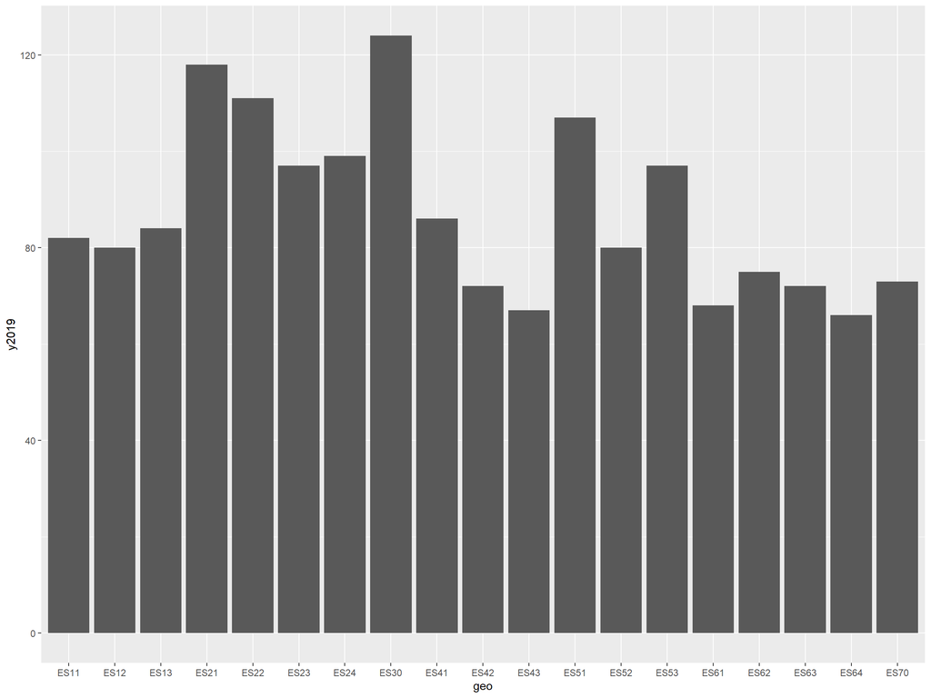

change mapping and geo

```r
ggplot(data = df,
       mapping = aes(x= geo, y= y2019))+
  geom_col()
```

the `geom_` can include several aesthetics options (alpha, colour, fill, group, shape, size, etc).

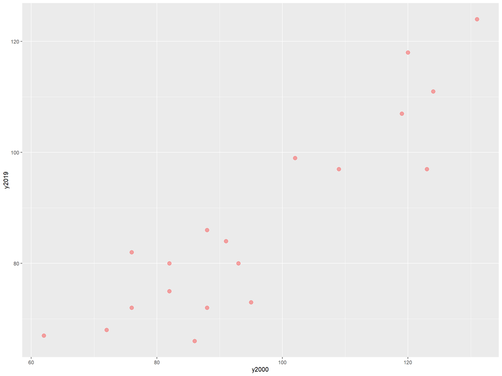

Change geom aesthetics

```r
ggplot(data = df,
       mapping = aes(x= y2000, y= y2019))+
  geom_point(alpha=1/3,
             colour="red",
             size=3)
```

We can have more than one geom. We can add a regression line with geom_smooth.

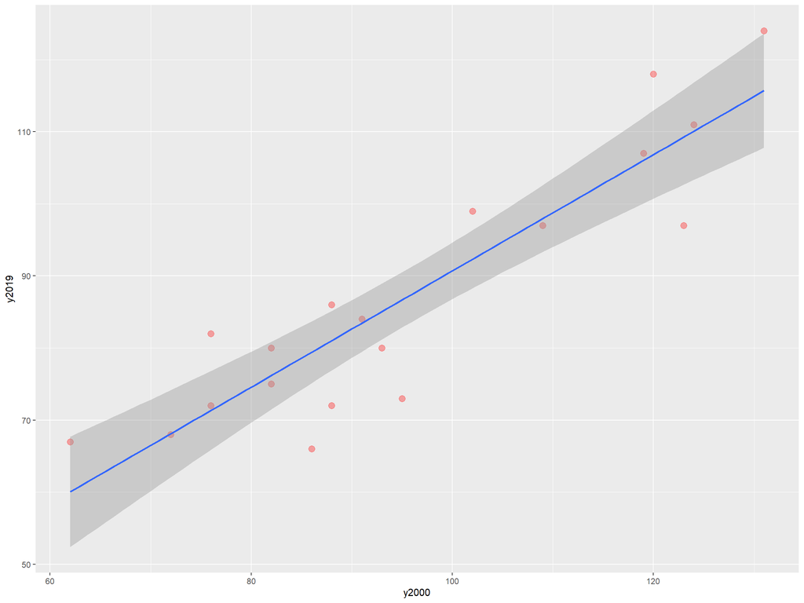

Add geom_smooth

```r
ggplot(data = df,
       mapping = aes(x= y2000, y= y2019))+
  geom_point(alpha=1/3,
             colour="red",
             size=3)+
  geom_smooth(method = "lm")
```

The chart indicates that there is a positive correlation between the values in 2000 and 2019 and that some regions are slightly outside the expected values of the regression.

## Groupings

In addition to mapping variables to the axes, they can also be mapped to characteristics. Let’s create a variable nuts 1 in the data.frame and map it to colour. We will have to remove the fixed mapping of colour inside geom and put it on the aes.

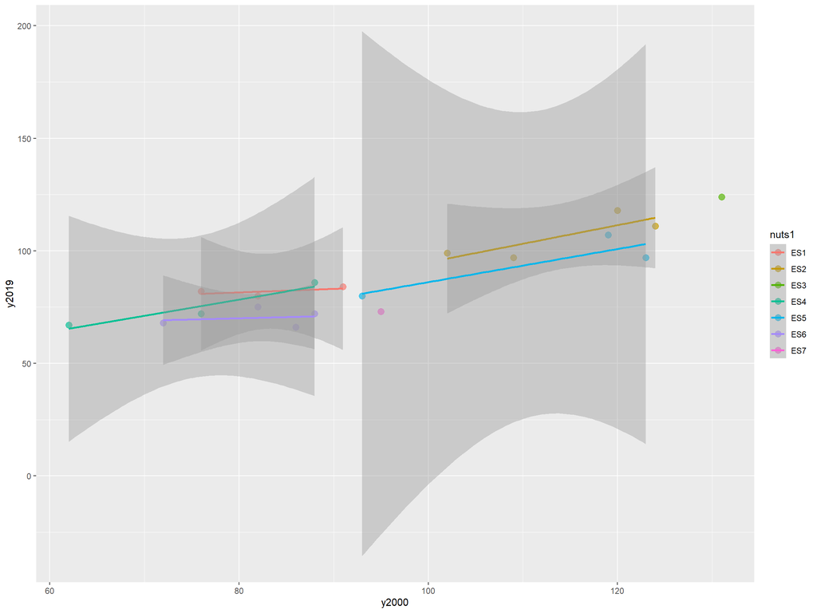

Add colour mapping

```r
df<- df %>%
  mutate(nuts1=str_sub(geo,1,3))

ggplot(data = df,
       mapping = aes(x= y2000, y= y2019, colour= nuts1))+
  geom_point(alpha=2/3,
             #colour="red",
             size=3)+
  geom_smooth(method = "lm")
```

Notice some things in this chart. All the geoms are automatically adjusted to the new aes mapping. We have a new legend explaining the mapping.

We could also map the size to the values in millions of euros, for example.

We could prefer to have the colour only in the points but have a single regression line. In general, geoms inherit the aes from the first ggplot function but we can use different ones if we specify individually the aes for each geom.

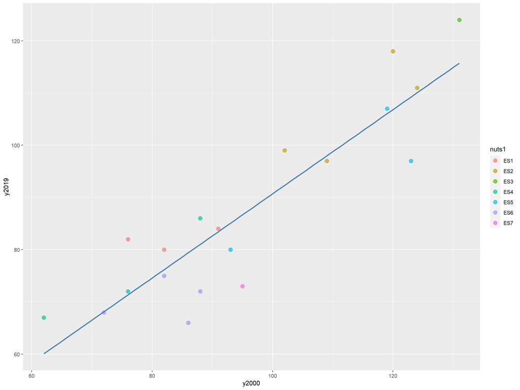

Individual mappings for geom

```r
ggplot(data = df)+
  geom_point(mapping = aes(x = y2000,
                           y = y2019,
                           colour = nuts1),
                           alpha=2/3,
                           size=3)+
  geom_smooth(mapping = aes(x = y2000,
                            y = y2019),
                            method = "lm",
                            se = FALSE,
                            colour = "steelblue")
```

## Scales

`scales_` functions allow to change the mapping between the variables and the axes, colours or any other characteristic we have mapped. Let’s change the axis to a logarithmic scale and the colour mappings using a set of colours that we define manually.

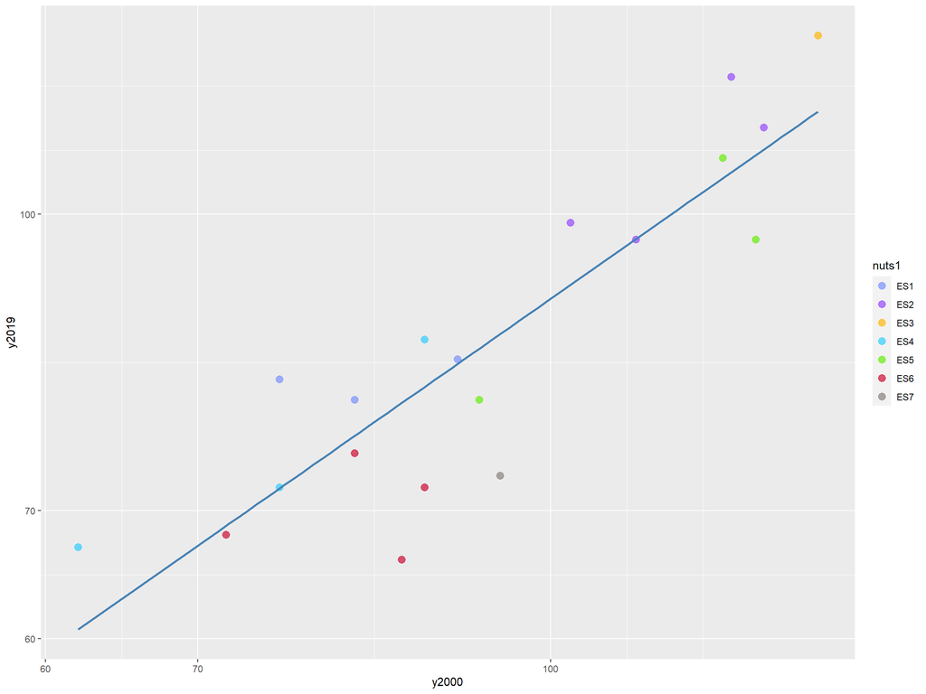

scales

```r
ggplot(data = df)+
  geom_point(mapping = aes(x = y2000,
                           y = y2019,
                           colour = nuts1),
                           alpha=2/3,
                           size=3)+
  geom_smooth(mapping = aes(x = y2000,
                            y = y2019),
                            method = "lm",
                            se = FALSE,
                            colour = "steelblue")+
  scale_x_log10()+
  scale_y_log10()+
  scale_color_manual(values = c( "#738CFF",
                                  "#9140FF",
                                  "#FFB300",
                                  "#26CCFF",
                                  "#5FED00",
                                  "#CC0029",
                                  "#847A77"))
```

## Facets

We could use also small graphs to get the view for nuts1 regions grouping instead of colours.

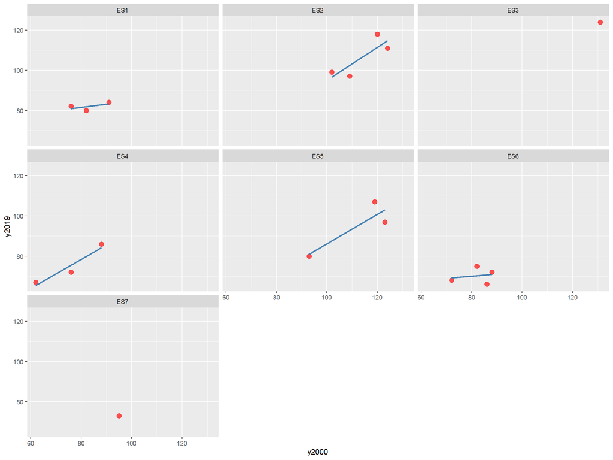

facets

```r
ggplot(data = df)+
  geom_point(mapping = aes(x = y2000,
                           y = y2019),
                           alpha=2/3,
                           size=3,
                           colour="red")+
  geom_smooth(mapping = aes(x = y2000,
                            y = y2019),
                            method = "lm",
                            se = FALSE,
                            colour = "steelblue")+
  facet_wrap(~nuts1)
```

## Labels

The `labs` function provides customized labels for the axes,legends, title, etc.

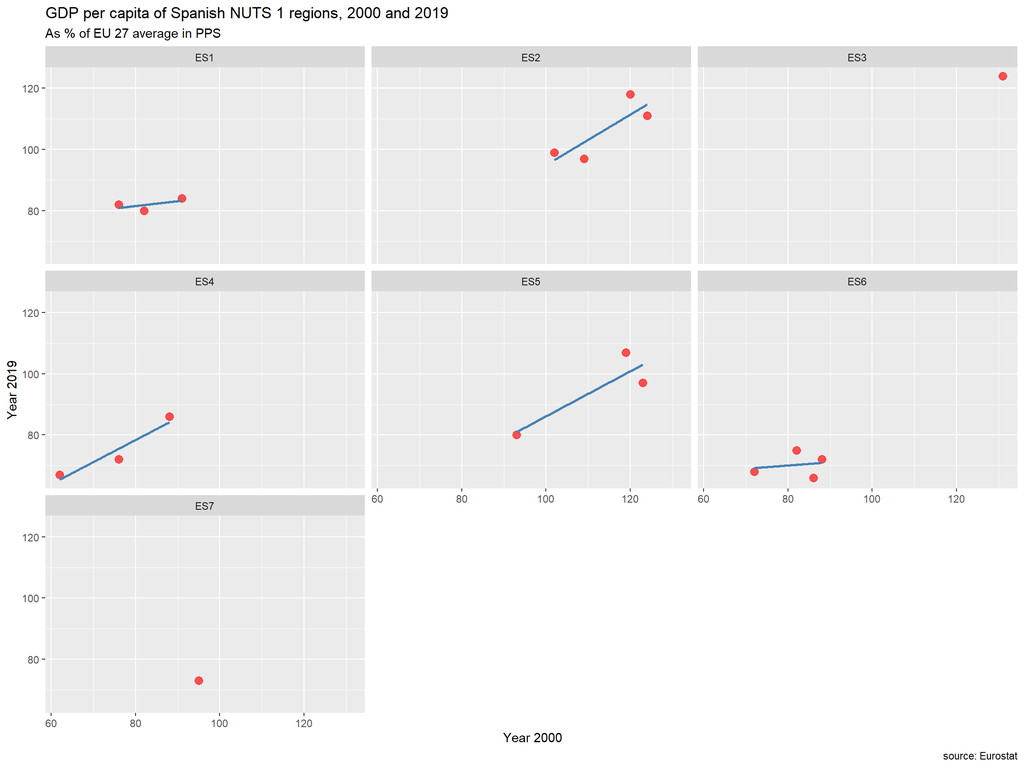

labs

```r
ggplot(data = df)+
  geom_point(mapping = aes(x = y2000,
                           y = y2019),
                           alpha=2/3,
                           size=3,
                           colour="red")+
  geom_smooth(mapping = aes(x = y2000,
                            y = y2019),
                            method = "lm",
                            se = FALSE,
                            colour = "steelblue")+
  facet_wrap(~nuts1)+
 labs(title = "GDP per capita of Spanish NUTS 1 regions, 2000 and 2019",
       subtitle = "As % of EU 27 average in PPS",
       caption = "source: Eurostat",
       x = " Year 2000",
       y = "Year 2019")
```

## Themes

`theme_` functions change the appearance of some none data related elements of the charts, like gridlines, background colours, placement of the legend.

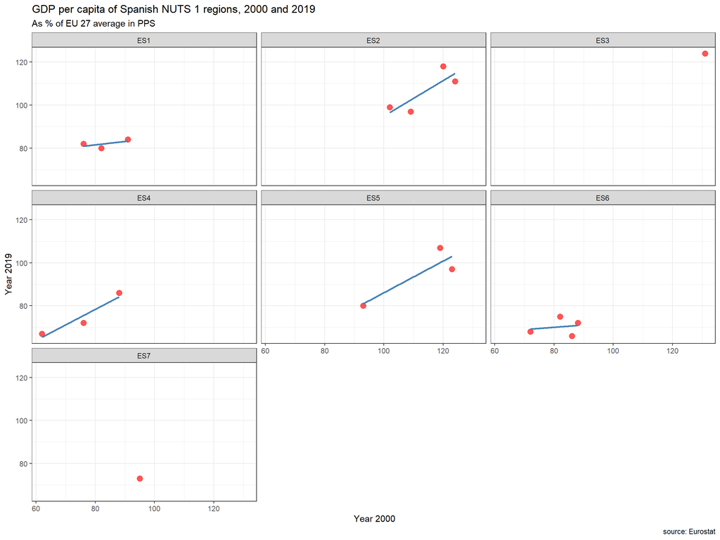

```r
ggplot(data = df)+
  geom_point(mapping = aes(x = y2000,
                           y = y2019),
                           alpha=2/3,
                           size=3,
                           colour="red")+
  geom_smooth(mapping = aes(x = y2000,
                            y = y2019),
                            method = "lm",
                            se = FALSE,
                            colour = "steelblue")+
  facet_wrap(~nuts1)+
 labs(title = "GDP per capita of Spanish NUTS 1 regions, 2000 and 2019",
       subtitle = "As % of EU 27 average in PPS",
       caption = "source: Eurostat",
       x = " Year 2000",
       y = "Year 2019")+
  theme_bw()
```

## Using more than 1 dataset

Normally we could prepare exactly the data we want to use for ggplot, but we can also use different datasets for different geoms.

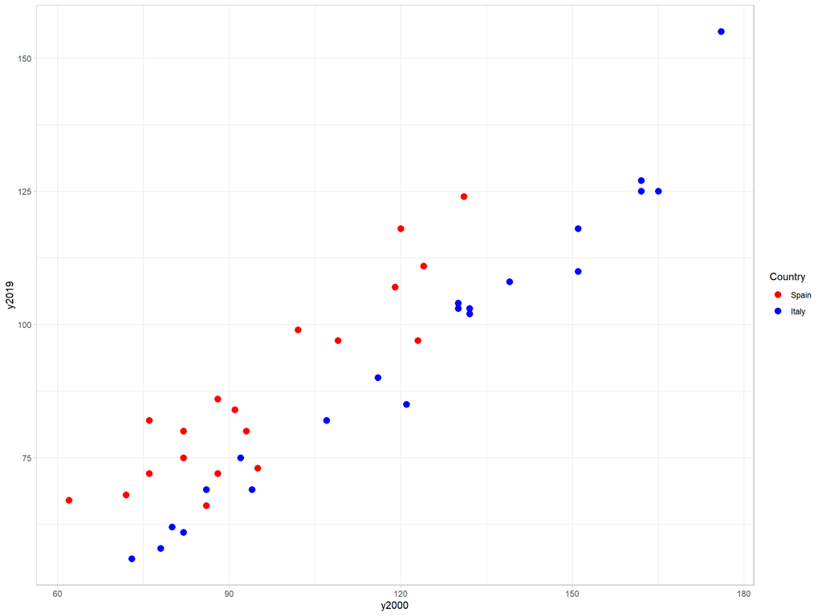

```r
df_it<- data.table::fread("data/gdp2v.csv") %>%
  filter(unit=="PPS_HAB_EU27_2020") %>%
  filter(time == 2000 | time == 2019) %>%
  mutate(country=str_sub(geo,1,2),
         nuts=str_length(geo)-2) %>%
  filter(country=="IT" &
         nuts==2) %>%
  select(geo,time,obs_value) %>%
  pivot_wider(names_from=time,
              values_from=obs_value,
              names_prefix = "y") %>%
   mutate(nuts1=str_sub(geo,1,3))

# little hack here
colors <- c("Spain" = "red", "Italy" = "blue")

ggplot()+
  geom_point(data=df, aes(x=y2000,
                          y=y2019,
                          colour= "Spain"),
                          size=3)+
  geom_point(data=df_it, aes(x=y2000,
                          y=y2019,
                          colour= "Italy"),
                          size=3)+
  scale_colour_manual(values=colors)+
  labs(colour="Country")+
  theme_light()
```

## Graphs as objects

ggplot charts can be assigned and saved as objects. We could save the object and then modify it.

```r
p <- ggplot(data = df,
       mapping = aes(x= y2000, y= y2019))+
  geom_point()

p <- p + labs(title="First chart")

p$data
```

```
## # A tibble: 19 x 4
##    geo   y2000 y2019 nuts1
##    <chr> <dbl> <dbl> <chr>
##  1 ES11     76    82 ES1
##  2 ES12     82    80 ES1
##  3 ES30    131   124 ES3
##  4 ES41     88    86 ES4
##  5 ES21    120   118 ES2
##  6 ES22    124   111 ES2
##  7 ES13     91    84 ES1
##  8 ES23    109    97 ES2
##  9 ES24    102    99 ES2
## 10 ES42     76    72 ES4
## 11 ES43     62    67 ES4
## 12 ES61     72    68 ES6
## 13 ES62     82    75 ES6
## 14 ES63     88    72 ES6
## 15 ES64     86    66 ES6
## 16 ES51    119   107 ES5
## 17 ES52     93    80 ES5
## 18 ES53    123    97 ES5
## 19 ES70     95    73 ES7
```

```r
p$mapping
```

[output not shown]

```r
p$labels
```

```
## $title
## [1] "First chart"
##
## $x
## [1] "y2000"
##
## $y
## [1] "y2019"
```

Saving p as an Rdata file will save the data used for the graphs and all the parameters.

# Customisizing charts

## Axes

We can customise numeric axis with `scale_*_continuous` and set the breaks and limits for example.

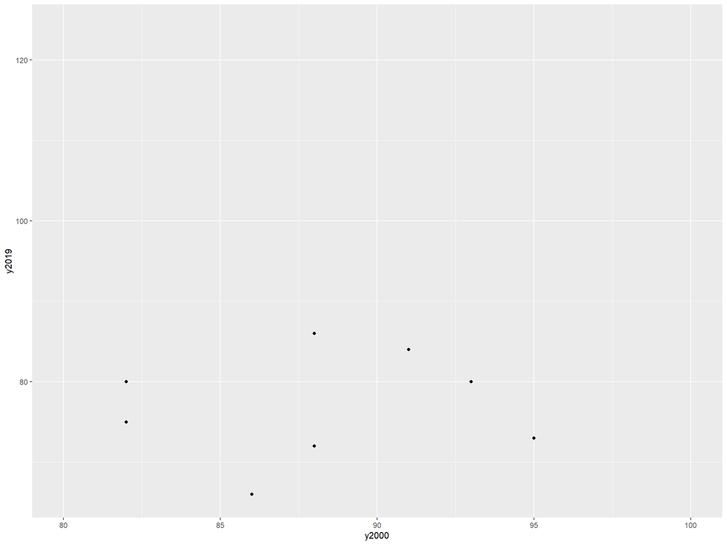

Customised numerical x axis limits

```r
 ggplot(data = df,
       mapping = aes(x= y2000, y= y2019))+
  geom_point()+
  scale_x_continuous(limits=c(80,100))
```

We can format the numeric labels with the `scales`package.

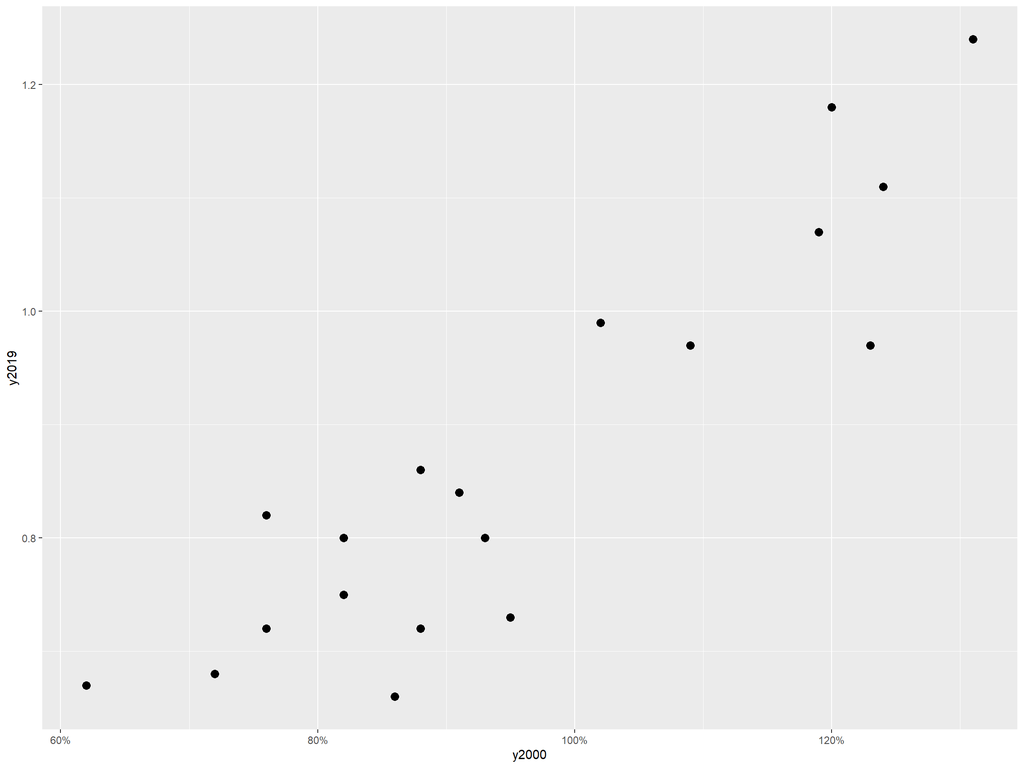

Customised numeric axis labels

```r
df %>%
  mutate(y2000=y2000/100,
         y2019=y2019/100) %>%
 ggplot(mapping = aes(x= y2000, y= y2019))+
  geom_point(size=3)+
 scale_x_continuous(labels= scales::percent)
```

See that ggplot is also pipeable and the .data argument can be brought directly from the data frame.

Discrete axis are modified with `scale_*_discrete`.

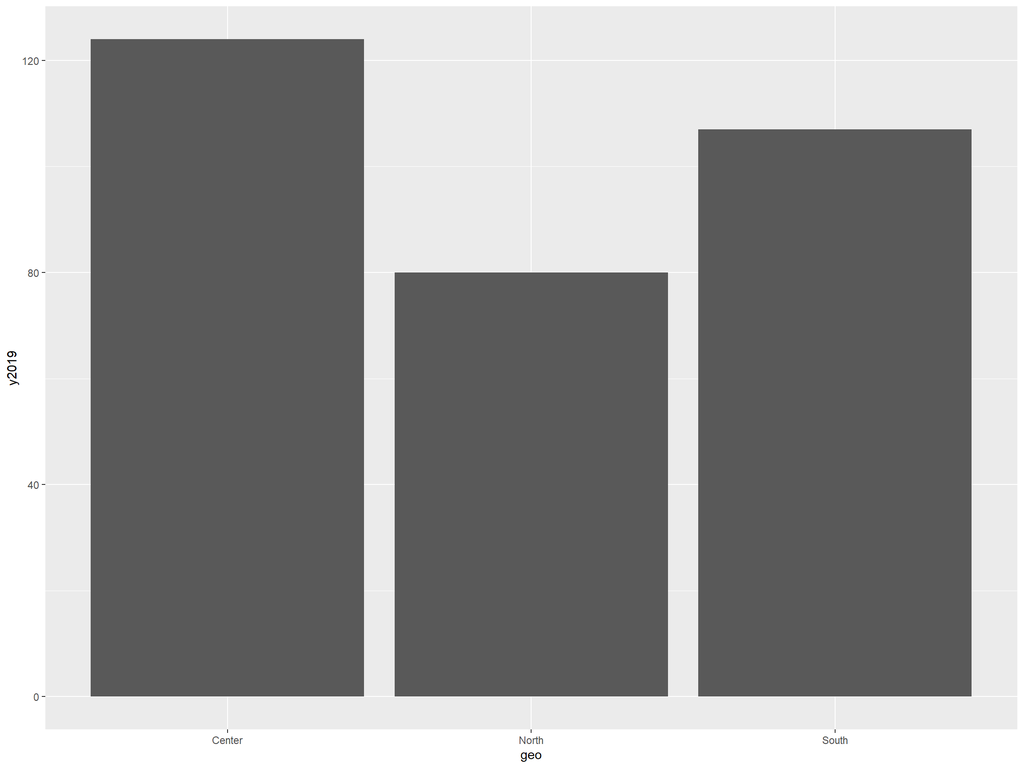

Customised x axis

```r
ggplot(data = df,
       mapping = aes(x= geo, y= y2019))+
  geom_col()+
  scale_x_discrete(limits=c("ES30","ES12","ES51"),
                   labels= c("Center", "North", "South"))
```

Date axis are modified with `scale_*_date`. It is useful to know some abreviations for the argument `date_labels`:

- %d day as a number (0-31)
- %a abbreviated weekday
- %A unabbreviated weekday
- %m month (00-12)
- %b abbreviated month
- %B unabbreviated month
- %y 2-digit year
- %Y 4-digit year

## Colours

We can manually specify individual colours in the `geom_*` with `colour =` or several colours with `scale_colour_manual` (or fill) but we have to provide the precise amount of colours needed. We can also let ggplot choose them for us or one of the available predefined colour palettes.

Some popular ones are `RColorBrewer` using `scale_color_brewer()`.

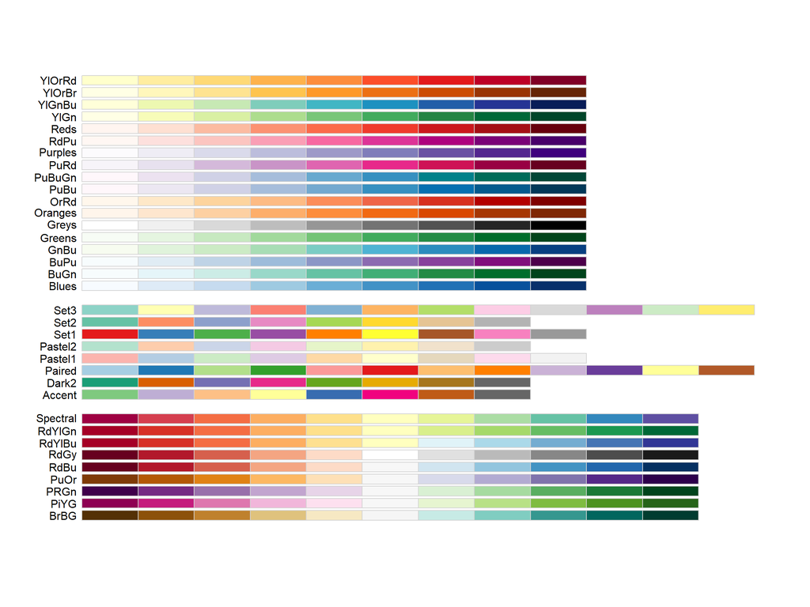

```r
RColorBrewer::display.brewer.all()
```

or viridis, which has several options (scale_colour_viridis_c, scale_colour_viridis_d) and does not limit the amount of colours.

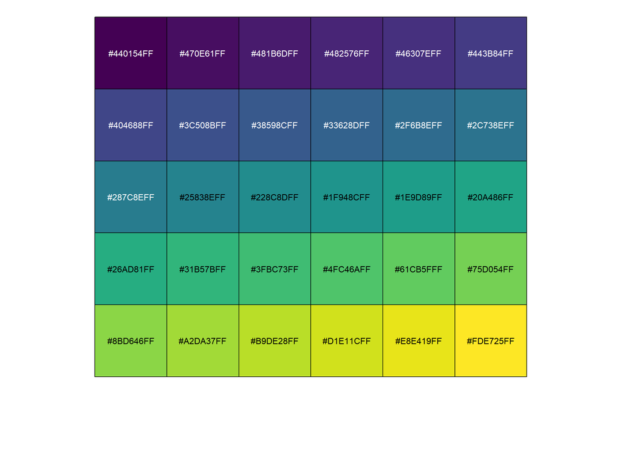

```r
library(viridis)
scales::show_col(viridis_pal()(30))
```

the library **{paletteer}** includes hundreds of palettes. You can use it in ggplot with `scale_color_paletteer_d("package::palette")` (or fill) or get the HEX codes of the palette with the function paletteer_d(), for example the colours of the palette `Grand Budapest` from the package `Wes Anderson`.

```r
library(wesanderson)
paletteer::paletteer_d("wesanderson::GrandBudapest1")
```

```
## <colors>
## #F1BB7BFF #FD6467FF #5B1A18FF #D67236FF
```

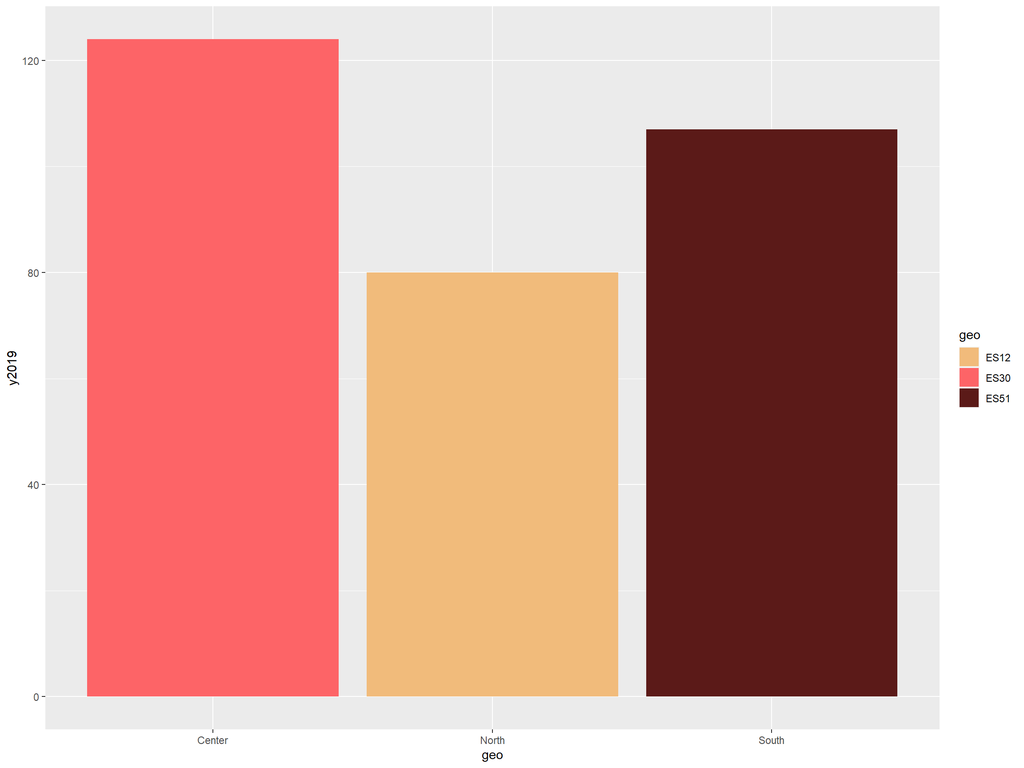

```r
ggplot(data = df,
       mapping = aes(x= geo, y= y2019, fill= geo))+
  geom_col()+
  scale_x_discrete(limits=c("ES30","ES12","ES51"),
                   labels= c("Center", "North", "South"))+
  paletteer::scale_fill_paletteer_d("wesanderson::GrandBudapest1")
```

## Points

We can change the usual points by different shapes or set the shape as a grouping argument.

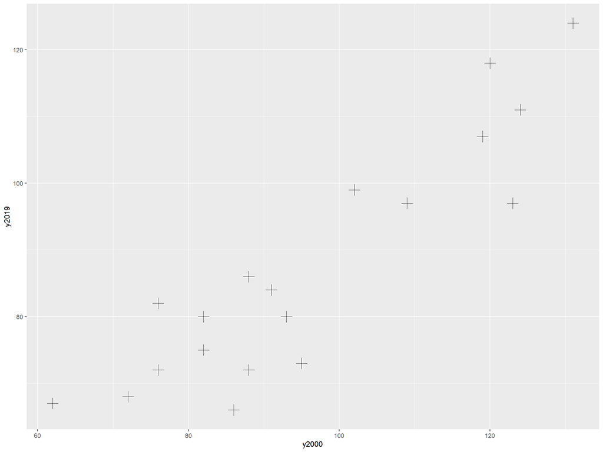

```r
 ggplot(data = df,
       mapping = aes(x= y2000, y= y2019))+
  geom_point(shape= 3, size=5)
```

## Lines

For lines we can change the size and the linetype.

## Fonts

We can apply the font using the `text` option in the theme `function`. We can also control the size of the font.

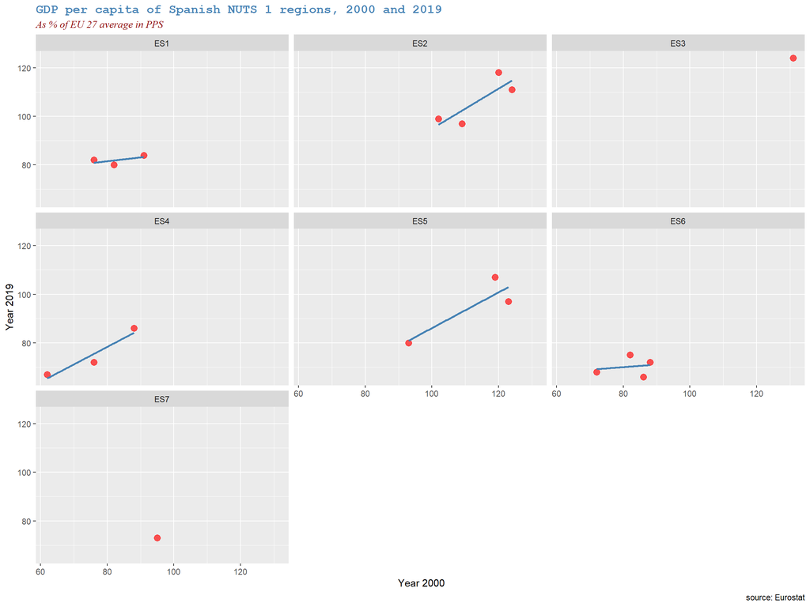

```r
ggplot(data = df)+
  geom_point(mapping = aes(x = y2000,
                           y = y2019),
                           alpha=2/3,
                           size=3,
                           colour="red")+
  geom_smooth(mapping = aes(x = y2000,
                            y = y2019),
                            method = "lm",
                            se = FALSE,
                            colour = "steelblue")+
  facet_wrap(~nuts1)+
 labs(title = "GDP per capita of Spanish NUTS 1 regions, 2000 and 2019",
       subtitle = "As % of EU 27 average in PPS",
       caption = "source: Eurostat",
       x = " Year 2000",
       y = "Year 2019")+
theme(plot.title = element_text(family = "mono",face="bold", colour="steelblue"),
      plot.subtitle = element_text(family = "serif",face="italic", colour="darkred"))
```

## Legends

Legends are automatically created when we map one variable to an element. We can change the legend position with `theme(legend.position = position)` which takes as arguments “bottom”, “left” or “none”if we do not want to include it but also coordinates that vary from 0 to 1 `c(x,y)`.

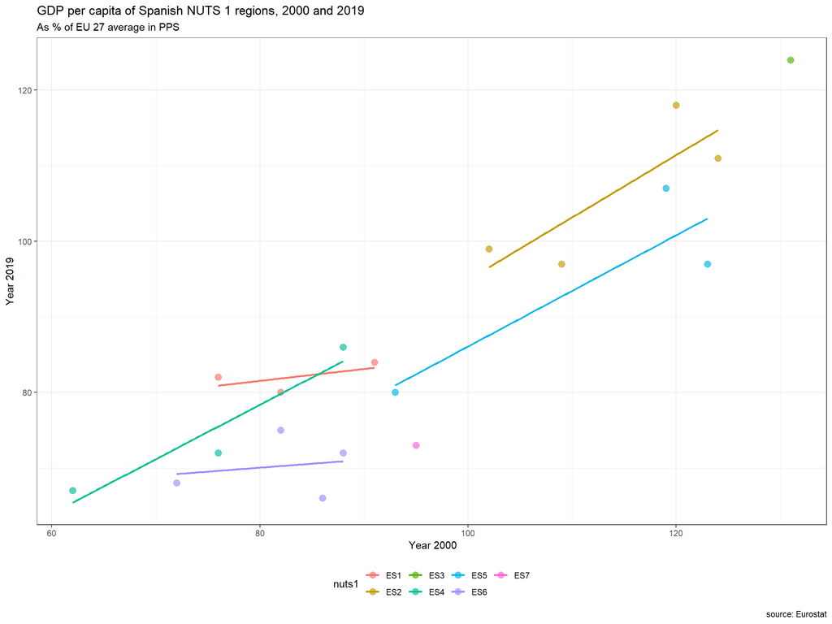

```r
ggplot(data = df)+
  geom_point(mapping = aes(x = y2000,
                           y = y2019,
                           colour=nuts1),
                           alpha=2/3,
                           size=3)+
  geom_smooth(mapping = aes(x = y2000,
                            y = y2019,
                            colour = nuts1),
                            method = "lm",
                            se = FALSE)+
 labs(title = "GDP per capita of Spanish NUTS 1 regions, 2000 and 2019",
       subtitle = "As % of EU 27 average in PPS",
       caption = "source: Eurostat",
       x = " Year 2000",
       y = "Year 2019")+
  theme_bw()+
  theme(legend.position = "bottom")
```

The legend title and some of attributes (colour, size, etc) can be changes in the `labs` function while others in `theme`, like `legend.title.align`.

## Labels

In the labs we can specify the labels of the title, sub-title, caption, of the axis, and the aesthetics we have used in the chart (colour, size, etc).

## Text

We can add directly text to the values with `geom_text` and `geom_label`.

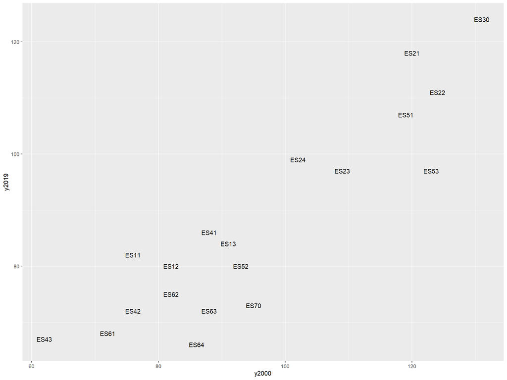

```r
 ggplot(data = df,
       mapping = aes(x= y2000, y= y2019, label= geo))+
  geom_text()
```

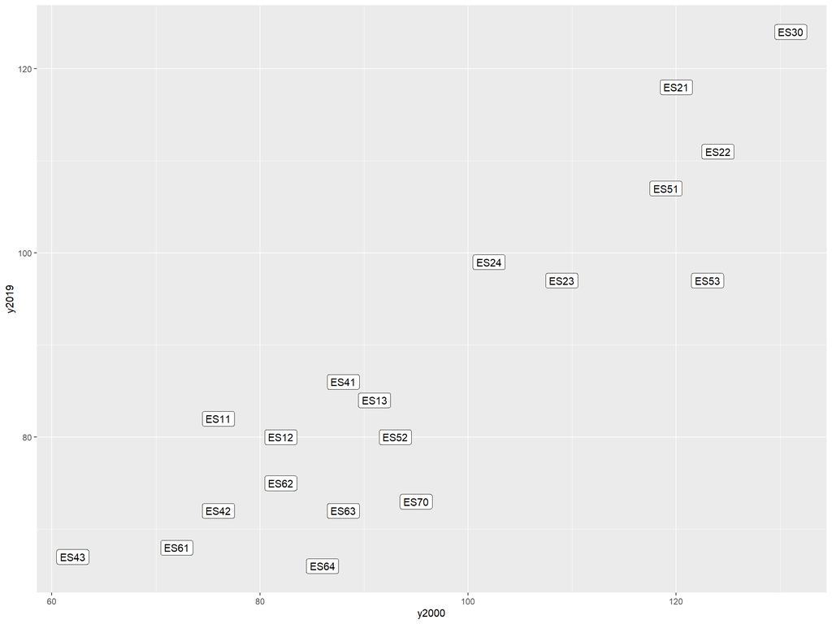

```r
 ggplot(data = df,
       mapping = aes(x= y2000, y= y2019, label= geo))+
  geom_label()
```

Sometimes we may only want to annotate something in the chart with `annotate`.

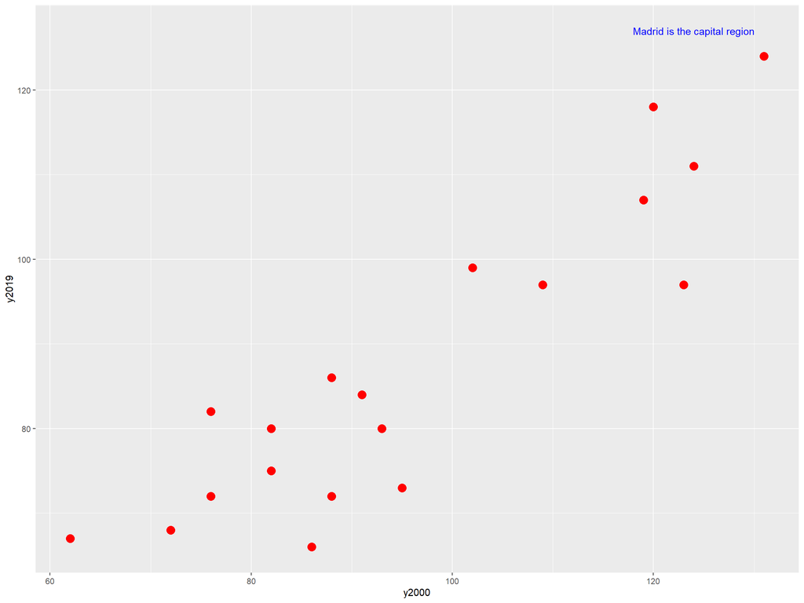

```r
 ggplot(data = df,
       mapping = aes(x= y2000, y= y2019))+
  geom_point(size=4, colour="red")+
  annotate("text",
           x=124,
           y=127,
           label="Madrid is the capital region",
           colour="blue")
```

We can also use annotate with “rect” or other elements.

## Adding lines

We can add horizontal and vertical lines with `geom_hline()` and `geom_vline()`. It is also possible to add arrows with `geom_segment()` and `geom_curve()`.

## Themes

Ggplot comes with a few pre-built themes for most elements that are controlled in theme. Additional popular ones are available in **{ggthemes}** or **{hrbrthemes}**.